# StatComp Project 1: 3D printer materials estimation

Ken Deng (s2617343)

# 1 The data

After loading the data set “filament1”, we can see that the data set has 86 samples, each containing 5 variables. **Index** and **Date** are index columns, **Material** are categorical variables, and **CAD_Weight** and **Actual_Weight** are numerical variables.

## 1.1 Missing value processing

We first use `is.na()` to determine whether there are missing values, and the result shows that our data set does not have missing values, so we can proceed to the next analysis.

```r
any(is.na(filament1))
```

```
## [1] FALSE
```

## 1.2 Numeric variable analysis

Then we use `summary()` to look at the distribution of numerical variables. Based on these quantiles, we can see that the distribution of **CAD_Weight** and **Actual_Weight** is similar, and **Actual_Weight** is slightly larger than **CAD_Weight**. This means that the actual printed weight will be heavier than its original design.

```r
summary(filament1[, c("CAD_Weight", "Actual_Weight")])
```

```
##    CAD_Weight    Actual_Weight
##  Min.   : 2.00   Min.   : 2.00
##  1st Qu.:19.00   1st Qu.:19.25
##  Median :33.00   Median :35.00
##  Mean   :34.71   Mean   :37.37
##  3rd Qu.:44.00   3rd Qu.:48.00
##  Max.   :88.00   Max.   :96.00
```

## 1.3 **Material** analysis

After the initial analysis, we use `ggplot` to plot the data for further discussion.

For categorical variable **Material**, we make a pie chart to check its distribution. Then we know that **Material** has a total of 6 categories, of which the frequency of “black”, “red” and “rate” is more than 20%, and the total proportion of these three materials is 77%.

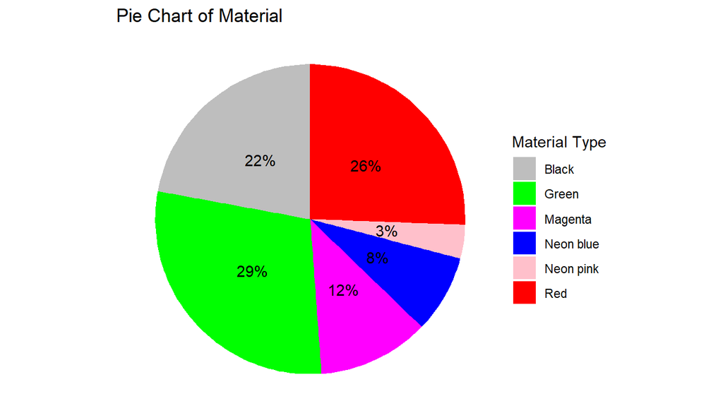

## 1.4 **CAD_Weight** and **Actual_Weight** analysis

Based on the previous analysis, we found that the distribution of **CAD_Weight** and **Actual_Weight** is similar, so we try to make a scatter plot to check the relationship between these two variables. The figure shows a strong linear correlation between the two variables, which is in line with our expectations.

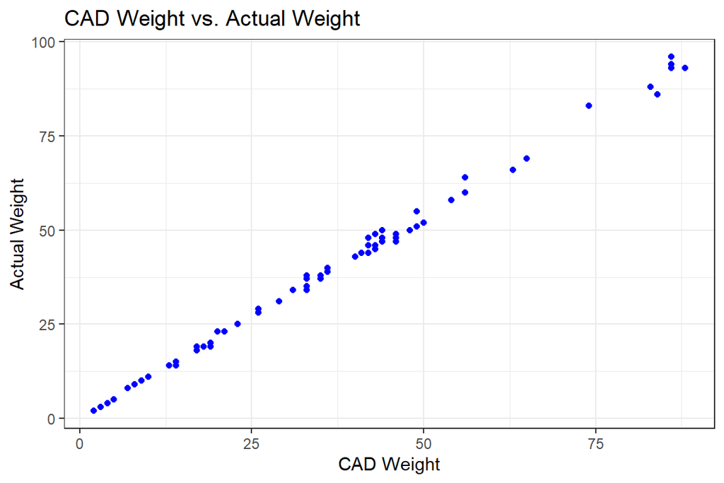

We further support our idea by calculating Pearson correlation coefficient, and through the results of `cor()`, we prove that the linear correlation between variables is strong.

Note that the Pearson correlation coefficient has the formula:
$$r_{XY} = \frac{\operatorname{Cov}(X, Y)}{\sigma_X \cdot \sigma_Y},$$
where $\operatorname{Cov}(X, Y)=\frac{1}{n} \sum_{i=1}^{n}\left(x_{i}-\bar{x}\right)\left(y_{i}-\bar{y}\right)$, $\sigma = \sqrt{\frac{1}{n-1} \sum_{i=1}^{n}\left(z_{i}-\bar{z}\right)^{2}}$.

```r
cor(filament1[, c("CAD_Weight", "Actual_Weight")])
```

```
##               CAD_Weight Actual_Weight
## CAD_Weight     1.0000000     0.9985251
## Actual_Weight  0.9985251     1.0000000
```

## 1.5 The effect of **Material** on **CAD_weight**

Considering that the actual weight of different printing materials may be different, we use the boxplot to investigate the change of **CAD_weight** between different **Material**.

From the figure, we can find that different **CAD_weight** distributions differ greatly, among which “Red” has the most dispersed distribution and “Magenta” has the most concentrated distribution but has 3 outliers.

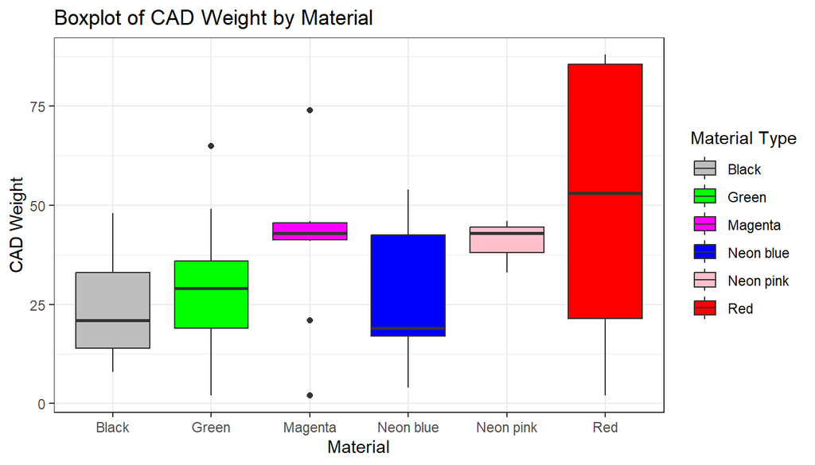

The purpose of ANOVA is to compare the mean square between groups with the mean square within groups to determine whether there is a significant difference between groups.

Through `aov()` analysis of variance, we further prove that there are significant differences in the distribution of **CAD_weight** for different materials, where the tested p-value < 0.001.

```r
anova <- aov(CAD_Weight ~ Material, data = filament1)
summary(anova)
```

```
##             Df Sum Sq Mean Sq F value   Pr(>F)
## Material     5  11115  2223.1   5.329 0.000281 ***
## Residuals   80  33372   417.2
## ---
## Signif. codes:  0 '***' 0.001 '**' 0.01 '*' 0.05 '.' 0.1 ' ' 1
```

# 2 Classical estimation

Now we use linear model A and B to fit **CAD_weight** and **Actual_Weight**.

- A: $y_i \sim \mathcal{N}(\beta_1 + \beta_2 x_i, \exp(\beta_3 + \beta_4 x_i))$
- B: $y_i \sim \mathcal{N}(\beta_1 + \beta_2 x_i, \exp(\beta_3) + \exp(\beta_4) x_i^2)$

, where $x_i$ is the observation from **CAD_weight**, $y_i$ is the observation from **Actual_Weight**.

For model parameter estimation, we define $\boldsymbol{\beta} = (\beta_1, \beta_2, \beta_3, \beta_4)^T$.

## 2.1 Model parameters estimation

We use the negative logarithmic likelihood function to estimate the parameters:
$$-\ell(\boldsymbol{\beta}) = -\log L(\boldsymbol{\beta};x, y) = -\log
f(y; x, \boldsymbol{\beta}) = -\sum_{i=1}^{n}\log f(y_i; x_i,
\boldsymbol{\beta})$$

We use `optim()` to find the model parameters corresponding to the minimum of the negative log-likelihood function.
$$\hat{\boldsymbol{\beta}} = \mathrm{argmin}_{\boldsymbol{\beta} \in
\mathbb{R}^4} -\ell(\boldsymbol{\beta})$$

For model A, we start with $\boldsymbol{\beta}_0 = (-0.1, 1.07, -2, 0.05)^T$ and then get $\hat{\boldsymbol{\beta}}$ and Hessian matrix at this point.

```
## $optimal
## [1] -0.08938095  1.07921160 -1.90262533  0.05566702
##
## $hessian
##              [,1]          [,2]         [,3]         [,4]
## [1,] 1.496208e+02  2505.6919704 1.764631e-02     0.410789
## [2,] 2.505692e+03 70489.6152578 4.128731e-01  -240.530065
## [3,] 1.764631e-02     0.4128731 4.300508e+01  1493.137953
## [4,] 4.107890e-01  -240.5300645 1.493138e+03 64416.544862
```

For model B, we start with $\boldsymbol{\beta}_0 = (-0.15, 1.07, -13.5, -6.5)^T$ and then get $\hat{\boldsymbol{\beta}}$ and Hessian matrix at this point.

```
## $optimal
## [1]  -0.1612982   1.0828644 -13.2127829  -6.6135928
##
## $hessian
##               [,1]          [,2]          [,3]          [,4]
## [1,]  1.046245e+03  4.390075e+03 -2.523432e-03 -6.110778e-03
## [2,]  4.390075e+03  6.408194e+04 -4.799581e-03 -2.784628e-01
## [3,] -2.523432e-03 -4.799581e-03  5.051994e-04 -5.481127e-05
## [4,] -6.110778e-03 -2.784628e-01 -5.481127e-05  4.299884e+01
```

## 2.2 Confidence interval construction

Based on the law of large numbers, we can assume that when the number of samples is large enough, the estimators are from a normal distribution.
$$\hat{\beta}_j \sim \mathcal{N}(\beta_j, \hat\sigma_j^2)$$

From this, we can deduce the construction of confidence interval:
$$\frac{\hat{\beta}_j - \beta_j}{\hat\sigma_j} \sim t_{n-p} \Rightarrow
CI:\hat{\beta}_j \pm t_{n-p}(\alpha/2)*\hat\sigma_j$$

Note that here $n = 86$ and $p = 4$.

For model A, we have:

```r
alpha <- 0.1
t_value <- qt(1 - alpha / 2, 82)

fit_A = filament1_estimate(data = filament1, model = "A")

se_A <- sqrt(diag(solve(fit_A$hessian)))
lower_A <- fit_A$optimal - t_value * se_A
upper_A <- fit_A$optimal + t_value * se_A
width_A <- upper_A - lower_A
```

| Name | Value | Lower | Upper | Width |
| --- | --- | --- | --- | --- |
| beta1 | -0.0893809 | -0.3031886 | 0.1244267 | 0.4276154 |
| beta2 | 1.0792116 | 1.0693608 | 1.0890624 | 0.0197017 |
| beta3 | -1.9026253 | -2.4768503 | -1.3284004 | 1.1484500 |
| beta4 | 0.0556670 | 0.0408299 | 0.0705042 | 0.0296743 |

For model B, we have:

```r
fit_B = filament1_estimate(data = filament1, model = "B")

se_B <- sqrt(diag(solve(fit_B$hessian)))
lower_B <- fit_B$optimal - t_value * se_B
upper_B <- fit_B$optimal + t_value * se_B
width_B <- upper_B - lower_B
```

| Name | Value | Lower | Upper | Width |
| --- | --- | --- | --- | --- |
| beta1 | -0.1612982 | -0.2222298 | -0.1003666 | 0.1218632 |
| beta2 | 1.0828644 | 1.0750789 | 1.0906500 | 0.0155711 |
| beta3 | -13.2127829 | -87.2300905 | 60.8045247 | 148.0346152 |
| beta4 | -6.6135928 | -6.8673004 | -6.3598852 | 0.5074152 |

By analyzing the estimators and confidence interval widths of different $\beta_j$:

1. The estimator of $\beta_1$ is less than 0 in both models, but the uncertainty is slightly higher in model A than in model B
2. The estimator of $\beta_2$ in both models is very accurate and takes the value of 1
3. The uncertainty of $\beta_3$ is high in model A, but it is much higher in model B than in model A
4. The estimator of $\beta_4$ in both models is very accurate

Above all, Model A may be more accurate than model B, and model variance depends to some extent on **CAD_weight**.

# 3 Bayesian estimation

Now we use Bayesian linear model to fit **CAD_weight** and **Actual_Weight**.

- model: $y_i \sim \mathcal{N}(\beta_1 + \beta_2 x_i, \beta_3 + \beta_4 x_i^2)$

, where $x_i$ is the observation from **CAD_weight**, $y_i$ is the observation from **Actual_Weight**.

For model parameter estimation, we define $\boldsymbol{\theta} = (\theta_1, \theta_2, \theta_3, \theta_4)^T = (\beta_1, \beta_2, \log\beta_3, \log\beta_4)^T$.

## 3.1 Prior density

Note that the printer operator assigns independent prior distributions as follows:
$$\begin{array}{l}
\theta_{1} \sim \operatorname{Normal}\left(0, \gamma_{1}\right) \\
\theta_{2} \sim \operatorname{Normal}\left(1, \gamma_{2}\right) \\
\theta_{3} \sim \log \operatorname{Exp}\left(\gamma_{3}\right) \\
\theta_{4} \sim \log \operatorname{Exp}\left(\gamma_{4}\right)
\end{array}$$

Hence the logarithm of the joint prior density can be estimated by `dnorm()` and `dlogexp()`:
$$\log p(\boldsymbol{\theta}) = \sum_{i=1}^{4}\log f_{\theta_i}(\theta_i;
\gamma_i)$$

## 3.2 Observation likelihood

The observation log-likelihood can be estimated by `dnorm()`
$$\log p(y|\boldsymbol{\theta}) = \log f_y(y|\boldsymbol{\theta}) =
\sum_{i=1}^{n}\log f_y(y_i|\boldsymbol{\theta})$$

Note that $\beta_3 = \exp\theta_3, \beta_4 = \exp\theta_4$

## 3.3 Posterior density

After ignoring the normalization constant, we can estimate the logarithm of the posterior density using Bayes formula.
$$p(\boldsymbol{\theta}| y) \propto p(\boldsymbol{\theta}) p(y |
\boldsymbol{\theta}) \Rightarrow \log p(\boldsymbol{\theta}| y) = \log
p(\boldsymbol{\theta}) + \log p(y | \boldsymbol{\theta})$$

## 3.4 Posterior mode

We can find the model parameters estimation corresponding to the maximum of the logarithm of the posterior density.
$$\hat{\boldsymbol{\theta}|y} = \mathrm{argmax}_{\boldsymbol{\theta} \in
\mathbb{R}^4} \log p(\boldsymbol{\theta}| y)$$

Note that matrix $S = -H^{-1}$ can be estimated by Hessian matrix at $\hat{\boldsymbol{\theta}|y}$.

## 3.5 Gaussian approximation

Let $\boldsymbol{\gamma}_0 = (1, 1, 1, 1)^T, \boldsymbol{\theta}_0 = (0, 0, 0, 0)^T$, we can use `optim()` to find the model parameters estimation.

```
## $mode
## [1] -0.1007081  1.0800213 -2.9817858 -6.7585702
##
## $hessian
##              [,1]         [,2]       [,3]       [,4]
## [1,]  -238.750166  -2573.81437   2.865874  -2.742917
## [2,] -2573.814374 -63698.40393 -14.451113  14.701761
## [3,]     2.865874    -14.45111  -1.468185  -3.658789
## [4,]    -2.742917     14.70176  -3.658789 -32.314181
##
## $S
##               [,1]          [,2]         [,3]          [,4]
## [1,]  0.0083022441 -3.433203e-04  0.030272279 -0.0042885091
## [2,] -0.0003433203  2.995883e-05 -0.001492856  0.0002118015
## [3,]  0.0302722786 -1.492856e-03  1.062908241 -0.1235970950
## [4,] -0.0042885091  2.118015e-04 -0.123597095  0.0454008900
```

Based on the law of large numbers, we can assume that when the number of samples is large enough, the estimators are from a normal distribution. Then we can use 4-dimension Gaussian distribution to approximate posterior distribution:
$$\boldsymbol{\theta}|y \sim \mathcal{N}_4 (\boldsymbol{\mu}, \Sigma),$$

where $\boldsymbol{\mu} = \hat{\boldsymbol{\theta}|y}, \Sigma = S$.

## 3.6 Importance sampling function

To perform importance sampling, first we use `rmvnorm()`` to extract a large number of samples from the Gaussian distribution. Note that $\beta_3 = \exp\theta_3, \beta_4 = \exp\theta_4$.

After sampling, we use a logarithmic weight formula to calculate the importance of each sample:
$$\log \omega_j = \log p(\boldsymbol{\theta}| y) - \log
\tilde{p}(\boldsymbol{\theta}| y),$$

where $\tilde{p}(\boldsymbol{\theta}| y)$ is the pdf of $\mathcal{N}_4 (\boldsymbol{\mu}, \Sigma)$

The calculated log-weights are normalized by `log_sum_exp`:
$$\tilde{\omega}_j = \frac{\omega_j}{\sum_{i=1}^n \omega_i} \Rightarrow
\log \tilde{\omega}_j = \log \omega_j - \log \sum_{i=1}^n \omega_i,$$

where $\log \tilde{\omega}_j$ is normalized log-weight.

Here are the first 10 samples we got:

```
##          beta1    beta2      beta3        beta4 log_weights
## 1  -0.05254697 1.080968 0.04816874 0.0010749940   -9.392642
## 2  -0.02356244 1.069615 0.10138206 0.0010297916   -9.605614
## 3  -0.13582452 1.077907 0.03716621 0.0016526701   -9.188114
## 4  -0.09497465 1.082148 0.02180792 0.0014571088   -9.346676
## 5  -0.14839766 1.080240 0.15167545 0.0011007370   -9.513725
## 6  -0.04616670 1.083758 0.03125297 0.0009232493   -9.943355
## 7  -0.26198105 1.093616 0.02776588 0.0013826276   -9.389507
## 8  -0.03792464 1.076867 0.09477865 0.0016064196   -9.021970
## 9   0.07577606 1.079620 0.06597329 0.0012262178   -8.848513
## 10 -0.07624810 1.071955 0.30793219 0.0009757332  -11.284979
```

Then we verify whether the normalized log-weights meet the requirements of normalization:

```r
sum(exp(IS$log_weights))
```

```
## [1] 1
```

## 3.7 Importance sampling

### 3.7.1 ECDF plot

After taking importance samples, we can use these weighted samples to estimate the ECDF(Empirical Cumulative Density Function):
$$F(x) = \sum_{i=1}^n \tilde{\omega}_i \mathbb{I}(x_i < x)$$

By plotting ECDF with different betas, we can compare the difference between weighted and unweighted sampling. It is observed that the ecdf with weighted sampling is smoother, which indicates that the weight to some extent eliminates the influence of random sampling on the estimation. By looking at beta values, we can also infer that $\beta_2$ and $\beta_4$ have a more concentrated distribution.

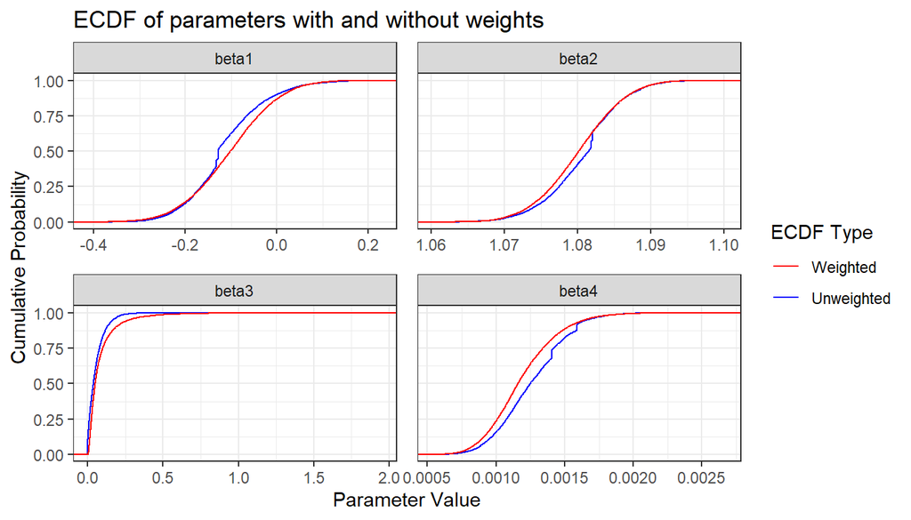

### 3.7.2 Prediction interval construction

Then, we use weighted samples to calculate quantiles to construct prediction intervals:
$$x_\alpha \ s.t. \ F(x_\alpha) = \sum_{i=1}^n \tilde{\omega}_i
\mathbb{I}(x_i < x_\alpha) = \alpha$$

`summarise()` is used to display the 90% confidence prediction intervals for all $\beta_j$.

```
## # A tibble: 4 × 3
##   name      lower   upper
##   <chr>     <dbl>   <dbl>
## 1 beta1 -0.240    0.0401
## 2 beta2  1.07     1.09
## 3 beta3  0.00107  0.169
## 4 beta4  0.000872 0.00166
```

### 3.7.3 Discussion on results

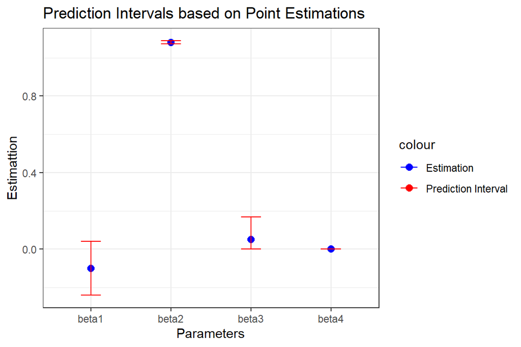

In terms of importance sampling, we use a scatter plot to observe the relationship between normalized log-weights and beta. We can see that in $\beta_1$, the weight of the sample with a small value is slightly larger than that of the sample with a large value. The weight distribution of $\beta_2$ and $\beta_4$ is relatively average. In $\beta_3$, the sample with a value close to 0 has a large dispersion degree and the larger the value, the lower the weight.

Note that the weights are calculated based on $\boldsymbol{\beta}$, so there can be differences in the weights for sample $\beta_j$s having similar values.

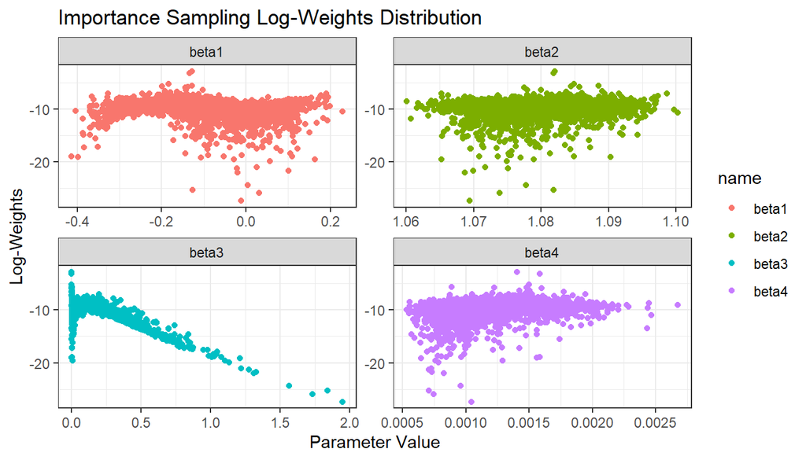

# 4 Code appendix

```r
#' Ken Deng, s2617343
#' Add your own function definitions on this file.

#' Log-Exponential density
#'
#' Compute the density or log-density for a Log-Exponential (LogExp)
#' distribution
#'
#' @param x vector of quantiles
#' @param rate vector of rates
#' @param log logical; if TRUE, the log-density is returned

dlogexp <- function(x, rate = 1, log = FALSE) {
  result <- log(rate) + x - rate * exp(x)
  if (!log) {
    exp(result)
  }
  result
}


#' Log-Sum-Exp
#'
#' Convenience function for computing log(sum(exp(x))) in a
#' numerically stable manner
#'
#' @param x numerical vector

log_sum_exp <- function(x) {
  max_x <- max(x, na.rm = TRUE)
  max_x + log(sum(exp(x - max_x)))
}

#' wquantile
#'
#' Calculates empirical sample quantiles with optional weights, for given probabilities.
#' Like in quantile(), the smallest observation corresponds to a probability of 0 and the largest to a probability of 1.
#' Interpolation between discrete values is done when type=7, as in quantile().
#' Use type=1 to only generate quantile values from the raw input samples.
#'
#' @param x numeric vector whose sample quantiles are wanted
#' NA and NaN values are not allowed in numeric vectors unless na.rm is TRUE
#' @param probs numeric vector of probabilities with values in [0,1]
#' @param na.rm logical; if true, any NA and NaN's are removed from x before the quantiles are computed
#' @param type numeric, 1 for no interpolation, or 7, for interpolated quantiles. Default is 7
#' @param weights    numeric vector of non-negative weights, the same length as x, or NULL. The weights are normalised to sum to 1. If NULL, then wquantile(x) behaves the same as quantile(x), with equal weight for each sample value

wquantile <- function(x, probs = seq(0, 1, 0.25), na.rm = FALSE, type = 7,
                      weights = NULL, ...) {
  if (is.null(weights) || (length(weights) == 1)) {
    weights <- rep(1, length(x))
  }
  stopifnot(all(weights >= 0))
  stopifnot(length(weights) == length(x))
  if (length(x) == 1) {
    return(rep(x, length(probs)))
  }
  n <- length(x)
  q <- numeric(length(probs))
  reorder <- order(x)
  weights <- weights[reorder]
  x <- x[reorder]
  wecdf <- pmin(1, cumsum(weights) / sum(weights))
  if (type == 1) {
  } else {
    weights2 <- (weights[-n] + weights[-1]) / 2
    wecdf2 <- pmin(1, cumsum(weights2) / sum(weights2))
  }
  for (pr_idx in seq_along(probs)) {
    pr <- probs[pr_idx]
    if (pr <= 0) {
      q[pr_idx] <- x[1]
    } else if (pr >= 1) {
      q[pr_idx] <- x[n]
    } else {
      if (type == 1) {
        j <- 1 + pmax(0, pmin(n - 1, sum(wecdf <= pr)))
        q[pr_idx] <- x[j]
      } else {
        j <- 1 + pmax(0, pmin(n - 2, sum(wecdf2 <= pr)))
        g <- (pr - c(0, wecdf2)[j]) / (wecdf2[j] - c(
          0,
          wecdf2
        )[j])
        q[pr_idx] <- (1 - g) * x[j] + g * x[j + 1]
      }
    }
  }
  q
}

#' Compute empirical weighted cumulative distribution
#'
#' Version of `ggplot2::stat_ecdf` that adds a `weights` property for each
#' observation, to produce an empirical weighted cumulative distribution function.
#' The empirical cumulative distribution function (ECDF) provides an alternative
#' visualisation of distribution. Compared to other visualisations that rely on
#' density (like [geom_histogram()]), the ECDF doesn't require any
#' tuning parameters and handles both continuous and discrete variables.
#' The downside is that it requires more training to accurately interpret,
#' and the underlying visual tasks are somewhat more challenging.
#'
# @inheritParams layer
# @inheritParams geom_point
#' @param na.rm If `FALSE` (the default), removes missing values with
#'    a warning.  If `TRUE` silently removes missing values.
#' @param n if NULL, do not interpolate. If not NULL, this is the number
#'   of points to interpolate with.
#' @param pad If `TRUE`, pad the ecdf with additional points (-Inf, 0)
#'   and (Inf, 1)
#' @section Computed variables:
#' \describe{
#'   \item{x}{x in data}
#'   \item{y}{cumulative density corresponding x}
#' }
#' @seealso wquantile
#' @export
#' @examples
#' library(ggplot2)
#'
#' n <- 100
#' df <- data.frame(
#'   x = c(rnorm(n, 0, 10), rnorm(n, 0, 10)),
#'   g = gl(2, n),
#'   w = c(rep(1 / n, n), sort(runif(n))^sqrt(n))
#' )
#' ggplot(df, aes(x, weights = w)) +
#'   stat_ewcdf(geom = "step")
#'
#' # Don't go to positive/negative infinity
#' ggplot(df, aes(x, weights = w)) +
#'   stat_ewcdf(geom = "step", pad = FALSE)
#'
#' # Multiple ECDFs
#' ggplot(df, aes(x, colour = g, weights = w)) +
#'   stat_ewcdf()
#' ggplot(df, aes(x, colour = g, weights = w)) +
#'   stat_ewcdf() +
#'   facet_wrap(vars(g), ncol = 1)
stat_ewcdf <- function(mapping = NULL, data = NULL,
                       geom = "step", position = "identity",
                       ...,
                       n = NULL,
                       pad = TRUE,
                       na.rm = FALSE,
                       show.legend = NA,
                       inherit.aes = TRUE) {
  ggplot2::layer(
    data = data,
    mapping = mapping,
    stat = StatEwcdf,
    geom = geom,
    position = position,
    show.legend = show.legend,
    inherit.aes = inherit.aes,
    params = list(
      n = n,
      pad = pad,
      na.rm = na.rm,
      ...
    )
  )
}


#' @title StatEwcdf ggproto object
#' @name StatEwcdf
#' @rdname StatEwcdf
#' @aliases StatEwcdf
#' @format NULL
#' @usage NULL
#' @export
#' @importFrom ggplot2 aes after_stat has_flipped_aes Stat
NULL

StatEwcdf <- ggplot2::ggproto(
  "StatEwcdf", ggplot2::Stat,
  required_aes = c("x|y", "weights"),
  dropped_aes = c("weights"),
  default_aes = ggplot2::aes(y = ggplot2::after_stat(y)),
  setup_params = function(data, params) {
    params$flipped_aes <-
      ggplot2::has_flipped_aes(data,
        params,
        main_is_orthogonal = FALSE,
        main_is_continuous = TRUE
      )

    has_x <- !(is.null(data$x) && is.null(params$x))
    has_y <- !(is.null(data$y) && is.null(params$y))
    if (!has_x && !has_y) {
      rlang::abort("stat_ewcdf() requires an x or y aesthetic.")
    }
    has_weights <- !(is.null(data$weights) && is.null(params$weights))
    #    if (!has_weights) {
    #      rlang::abort("stat_ewcdf() requires a weights aesthetic.")
    #    }
```

```r
    params
  },
  compute_group = function(data, scales, n = NULL, pad = TRUE, flipped_aes = FALSE) {
    data <- flip_data(data, flipped_aes)
    # If n is NULL, use raw values; otherwise interpolate
    if (is.null(n)) {
      x <- unique(data$x)
    } else {
      x <- seq(min(data$x), max(data$x), length.out = n)
    }

    if (pad) {
      x <- c(-Inf, x, Inf)
    }
    if (is.null(data$weights)) {
      data_ecdf <- ecdf(data$x)(x)
    } else {
      data_ecdf <-
        spatstat.geom::ewcdf(
          data$x,
          weights = data$weights / sum(abs(data$weights))
        )(x)
    }

    df_ecdf <- vctrs::new_data_frame(list(x = x, y = data_ecdf), n = length(x))
    df_ecdf$flipped_aes <- flipped_aes
    ggplot2::flip_data(df_ecdf, flipped_aes)
  }
)

#' Neg-Log-Likelihood
#'
#' According to the selected model, the negative log-likelihood function is calculated
#'
#' @param beta model parameter
#' @param data data.frame containing CAD_Weight and Actual_Weight
#' @param model model selection, A or B

neg_log_like <- function(beta, data, model) {
  X.vec <- data$CAD_Weight
  Y.vec <- data$Actual_Weight

  if (model == "A") {
    log.dense.vec <- dnorm(Y.vec,
      mean = beta[1] + beta[2] * X.vec,
      sd = sqrt(exp(beta[3] + beta[4] * X.vec)),
      log = TRUE
    )
    return(-sum(log.dense.vec)) # return negative log_likelihood
  } else if (model == "B") {
    log.dense.vec <- dnorm(Y.vec,
      mean = beta[1] + beta[2] * X.vec,
      sd = sqrt(exp(beta[3]) + exp(beta[4]) * X.vec^2),
      log = TRUE
    )
    return(-sum(log.dense.vec)) # return negative log_likelihood
  } else {
    stop("Unknown model. Please specify model A or B.")
  }
}

#' Model parameter estimation
#'
#' According to the selected model,
#' optim() is used to perform convergence calculation from different initial values,
#' and finally the optimal model parameters and corresponding hessian matrix are returned
#'
#' @param data data.frame containing CAD_Weight and Actual_Weight
#' @param model model selection, A or B

filament1_estimate <- function(data, model) {
  if (model == "A") {
    beta0 <- c(-0.1, 1.07, -2, 0.05)
    result <- optim(
      par = beta0,
      fn = neg_log_like,
      data = data,
      model = model,
      hessian = TRUE
    )
    return(list(optimal = result$par, hessian = result$hessian))
    # return model parameters estimation and Hessian matrix at estimators
  } else {
    beta0 <- c(-0.15, 1.07, -13.5, -6.5)
    result <- optim(
      par = beta0,
      fn = neg_log_like,
      data = data,
      model = model,
      hessian = TRUE
    )
    return(list(optimal = result$par, hessian = result$hessian))
    # return model parameters estimation and Hessian matrix at estimators
  }
}

#' Log_prior_density
#'
#' Assuming that the model parameters are also random variables,
#' the prior logarithmic probability density is calculated
#'
#' @param theta model parameters
#' @param params parameters of the prior distribution of theta

log_prior_density <- function(theta, params) {
  log.d1 <- dnorm(theta[1], mean = 0, sd = sqrt(params[1]), log = TRUE)
  log.d2 <- dnorm(theta[2], mean = 1, sd = sqrt(params[2]), log = TRUE)
  log.d3 <- dlogexp(theta[3], rate = params[3], log = TRUE)
  log.d4 <- dlogexp(theta[4], rate = params[4], log = TRUE)
  log.dense.vec <- c(log.d1, log.d2, log.d3, log.d4)
  return(sum(log.dense.vec)) # return log joint density
}

#' Log_likelihood
#'
#' Calculate the log-likelihood function of the model parameters for given samples
#'
#' @param theta model parameters
#' @param x x is used to compute the likelihood function as parameter
#' @param y y is used to compute the likelihood function as parameter

log_like <- function(theta, x, y) {
  log.dense.vec <- dnorm(y,
    mean = theta[1] + theta[2] * x,
    sd = sqrt(exp(theta[3]) + exp(theta[4]) * (x)^2),
    log = TRUE
  )
  return(sum(log.dense.vec)) # return log-likelihood
}

#' Log_posterior_density
#'
#' Calculate the probability density of the posterior distribution of the model parameters
#'
#' @param theta model parameters
#' @param x x is used to compute the likelihood function as parameter
#' @param y y is used to compute the likelihood function as parameter
#' @param params parameters of the prior distribution of theta

log_posterior_density <- function(theta, x, y, params) {
  return(log_prior_density(theta = theta, params = params) + log_like(theta = theta, x = x, y = y))
  # return log posterior density
}

#' Approximation of the mean and covariance matrix of a Gaussian distribution
#'
#' optim() is used to calculate the maximum point and hessian matrix
#' of the probability density of the posterior distribution,
#' and returns the inverse of the maximum point and the negative hessian matrix
#'
#' @param theta_start The initial theta of the optim() process
#' @param x x is used to compute the likelihood function as parameter
#' @param y y is used to compute the likelihood function as parameter
#' @param params parameters of the prior distribution of theta

posterior_mode <- function(theta_start, x, y, params) {
  result <- optim(
    par = theta_start,
    fn = log_posterior_density,
    x = x, y = y, params = params,
    hessian = TRUE,
    control = list(fnscale = -1)
  ) # Do maximisation instead of minimisation
  S <- solve(-result$hessian) # Compute the inverse of a negative hessian matrix
  return(list(mode = result$par, hessian = result$hessian, S = S))
  # return model parameters estimation and Hessian and S matrix at estimators
}

#' Importance Sampling
#'
#' The approximate Gaussian distribution is used to sample,
#' and the weights are set for each sample to better approximate the original distribution
#'
#' @param N number of samples
#' @param mu approximate Gaussian distribution mean
#' @param S covariance matrix of approximate Gaussian distribution
#' @param x x is used to compute the likelihood function as parameter
#' @param y y is used to compute the likelihood function as parameter
#' @param params parameters of the prior distribution of theta
```

```r
do_importance <- function(N, mu, S, x, y, params) {
  X <- rmvnorm(N, mean = mu, sigma = S)
  log.weights <- numeric(N)
  for (i in 1:N) {
    log.weights[i] <- log_posterior_density(X[i, ], x = x, y = y, params = params) - dmvnorm(X[i, ], mean = mu, sigma = S, log = TRUE)
    # Compute the logarithm of weights
  }
  normalized.log.weights <- log.weights - log_sum_exp(x = log.weights) # Normalization
  return(data.frame(beta1 = X[, 1], beta2 = X[, 2], beta3 = exp(X[, 3]), beta4 = exp(X[, 4]), log_weights = normalized.log.weights))
  # return all samples and corresponding normalized log-weight
}

#' Calculated prediction interval
#'
#' For a given set of weighted samples,
#' the quantile is calculated to construct the prediction interval
#'
#' @param x samples
#' @param weights weight of samples
#' @param prob the probability of the quantile, formatted as c(alpha, 1 - alpha)

make_CI <- function(x, weights, prob) {
  quantiles <- wquantile(x, probs = prob, weights = weights)
  return(data.frame(lower = min(quantiles), upper = max(quantiles)))
  # return prediction interval estimation based on samples with normalized weight
}
```